# Week 4, Day 1

Emily He

9/27/2020

Let’s continue working with enrollment data. I have downloaded 5 years of fall enrollment data in to the `raw_data` directory from the [official source](https://registrar.fas.harvard.edu/faculty-staff/courses/enrollment/archived-course-enrollment-reports).

### Scene 1

**Prompt:** Write a pipe which creates an object named `d_2019` by reading in and cleaning up the data from Fall 2019. (You will need to examine the file names to determine which file this is.) You may consult and re-use the code from last week. The variable names in the tibble should be `id`, `title`, `name`, `department` and `u_grad`. Keep only classes with more than 10 undergrads enrolled.

```
## # A tibble: 555 x 5
##    id     title      name                       department                u_grad
##    <chr>  <chr>      <chr>                      <chr>                      <dbl>
##  1 000018 MUSIC 18A  Harvard Jazz Band          Music                         11
##  2 000025 MUSIC 25   Music Festivals            Music                         17
##  3 107341 GENED 1076 Equity in American Educat… General Education            154
##  4 107367 PHYSCI 10  Quant, Stat, & Comp Chemi… Chemistry & Chemical Bio…     22
##  5 107425 ECON 1450  Political Economy of Reli… Economics                     18
##  6 107464 GENED 1011 Contemporary Develop Coun… General Education             61
##  7 107669 GENED 1033 Conflict Resolution in a … General Education             57
##  8 107677 COMPSCI 2… Adv. Machine Learning      Computer Science              71
##  9 107821 GENED 1120 Politic. Econ of Globaliz… General Education            122
## 10 108398 GENED 1020 Security                   General Education            243
## # … with 545 more rows
```

### Scene 2

**Prompt:** We could copy/paste this code 5 times, adjust the files names, and then read in each file. But, as you know from Chapter 4, that is a bad idea. It also scales very poorly. Create a function called `read_enrollent` which takes one argument, `file`. Use that function to read in the data from fall 2019 and assign it to an object called `d_2019_take_2`. Do you get the same answer as you did in Scene 1?

```
## # A tibble: 555 x 5
##    id     title      name                       department                u_grad
##    <chr>  <chr>      <chr>                      <chr>                      <dbl>
##  1 000018 MUSIC 18A  Harvard Jazz Band          Music                         11
##  2 000025 MUSIC 25   Music Festivals            Music                         17
##  3 107341 GENED 1076 Equity in American Educat… General Education            154
##  4 107367 PHYSCI 10  Quant, Stat, & Comp Chemi… Chemistry & Chemical Bio…     22
##  5 107425 ECON 1450  Political Economy of Reli… Economics                     18
##  6 107464 GENED 1011 Contemporary Develop Coun… General Education             61
##  7 107669 GENED 1033 Conflict Resolution in a … General Education             57
##  8 107677 COMPSCI 2… Adv. Machine Learning      Computer Science              71
##  9 107821 GENED 1120 Politic. Econ of Globaliz… General Education            122
## 10 108398 GENED 1020 Security                   General Education            243
## # … with 545 more rows
```

### Scene 3

**Prompt:** Call `read_enrollent()` five times, once for each of our data sets. Note how different the file names are. Real data is messy! Assign the result of each call to an object, `d_2019`, `d_2018` and so on. Should be easy . . .

Arrg! Depending in how you wrote `read_enrollment()`, you will probably be getting an error, for at least some of the years. How annoying that Harvard changes the format! Make your function flexible enough to deal with all these files. Hint: You need to add at least one argument in addition to `file` so that you can change the behavior of the function when you call it. Give that new argument a sensible default.

```
## # A tibble: 555 x 5
##    id     title      name                       department                u_grad
##    <chr>  <chr>      <chr>                      <chr>                      <dbl>
##  1 000018 MUSIC 18A  Harvard Jazz Band          Music                         11
##  2 000025 MUSIC 25   Music Festivals            Music                         17
##  3 107341 GENED 1076 Equity in American Educat… General Education            154
##  4 107367 PHYSCI 10  Quant, Stat, & Comp Chemi… Chemistry & Chemical Bio…     22
##  5 107425 ECON 1450  Political Economy of Reli… Economics                     18
##  6 107464 GENED 1011 Contemporary Develop Coun… General Education             61
##  7 107669 GENED 1033 Conflict Resolution in a … General Education             57
##  8 107677 COMPSCI 2… Adv. Machine Learning      Computer Science              71
##  9 107821 GENED 1120 Politic. Econ of Globaliz… General Education            122
## 10 108398 GENED 1020 Security                   General Education            243
## # … with 545 more rows
```

```
## # A tibble: 548 x 5
##    id     title      name                       department                u_grad
##    <chr>  <chr>      <chr>                      <chr>                      <dbl>
##  1 000018 MUSIC 18A  Harvard Jazz Band          Music                         12
##  2 107340 FRSEMR 26F Dreams: Our Mind by Night  Freshman Seminars             14
##  3 107341 US-WORLD … Equity in American Educat… General Education            150
##  4 107367 PHYSCI 10  Quantum & Statistical Fou… Chemistry & Chemical Bio…     15
##  5 107425 ECON 1450  Political Economy of Reli… Economics                     17
##  6 107464 SOCWORLD … Contemporary Develop Coun… General Education             17
##  7 107669 GHHP 60    Negotiation and Conflict … Global Health & Health P…     45
##  8 107677 COMPSCI 2… Adv. Machine Learning      Computer Science              29
##  9 107973 HIST 1155  Early Modern Europe, 1450… History                       32
## 10 108161 CULTBLF 51 Making the Middle Ages     General Education             34
## # … with 538 more rows
```

```
## # A tibble: 529 x 5
##    id     title      name                       department                u_grad
##    <chr>  <chr>      <chr>                      <chr>                      <dbl>
##  1 000018 MUSIC 18A  Harvard Jazz Band          Music                         12
##  2 000177 MUSIC 177  Creative Music: Adv. Ense… Music                         19
##  3 107341 US-WORLD … Equity in American Educat… General Education            149
##  4 107425 ECON 1450  Religion and Political Ec… Economics                     11
##  5 107464 SOCWORLD … Contemporary Develop Coun… General Education             97
##  6 107669 GHHP 60    Negotiation and Conflict … Global Health & Health P…     41
##  7 107677 COMPSCI 2… Adv. Machine Learning      Computer Science              55
##  8 107821 ECON 1400  The Future of Globalizati… Economics                     92
##  9 107859 RELIGION … Incarnation and Desire     Religion, The Study of        12
## 10 107925 HIST 1911  Pacific History            History                       15
## # … with 519 more rows
```

```
## # A tibble: 519 x 5
##    id     title       name                      department                u_grad
##    <chr>  <chr>       <chr>                     <chr>                      <dbl>
##  1 107340 FRSEMR 26F  Dreams: Our Mind by Night Freshman Seminars             13
##  2 107341 US-WORLD 35 Equity in American Educa… General Education            143
##  3 107349 MODMDEST 1… Intro Modern Middle East  Near Eastern Languages &…     16
##  4 107367 PHYSCI 10   Quantum & Statistical Fo… Chemistry & Chemical Bio…     31
##  5 107464 SOCWORLD 47 Contemporary Develop Cou… General Education             28
##  6 107669 GHHP 60     Negotiation and Conflict… Global Health & Health P…     45
##  7 107821 ECON 1400   The Future of Globalizat… Economics                    162
##  8 107858 HISTSCI 136 History of Biotechnology  History of Science           144
##  9 107859 RELIGION 40 Incarnation and Desire    Religion, The Study of        24
## 10 107880 ETHRSON 31  The Philosopher and the … General Education            121
## # … with 509 more rows
```

```
## # A tibble: 505 x 5
##    id     title      name                       department                u_grad
##    <chr>  <chr>      <chr>                      <chr>                      <dbl>
##  1 107340 FRSEMR 26F Dreams: Our Mind by Night  Freshman Seminars             14
##  2 107341 US-WORLD … Equity in American Educat… General Education             72
##  3 107367 PHYSCI 10  Quantum & Statistical Fou… Chemistry & Chemical Bio…     27
##  4 107397 ENG-SCI 1… Phys & Chem:Contxt Global… Engineering Sciences          11
##  5 107464 SOCWORLD … Contemporary Develop Coun… General Education             71
##  6 107669 GHHP 60    Negotiation and Conflict … Global Health & Health P…     34
##  7 107677 COMPSCI 2… Adv. Machine Learning      Computer Science              41
##  8 107712 US-WORLD … Innovation & Entrepreneur… General Education             93
##  9 107821 ECON 1400  The Future of Globalizati… Economics                    152
## 10 108257 FRSEMR 25X Human Brain in Health and  Freshman Seminars             15
## # … with 495 more rows
```

### Scene 4

**Prompt:** Combine the five tibbles which you have into a single tibble which can then be used for analysis and graphics. There are many ways to do this, but we recommend `bind_rows()`. Hint: make use of the `.id` argument, which may be aided by placing the tibbles in a list.

```
## # A tibble: 2,656 x 6
##     year id     title      name                   department              u_grad
##    <dbl> <chr>  <chr>      <chr>                  <chr>                    <dbl>
##  1  2015 107340 FRSEMR 26F Dreams: Our Mind by N… Freshman Seminars           14
##  2  2015 107341 US-WORLD … Equity in American Ed… General Education           72
##  3  2015 107367 PHYSCI 10  Quantum & Statistical… Chemistry & Chemical B…     27
##  4  2015 107397 ENG-SCI 1… Phys & Chem:Contxt Gl… Engineering Sciences        11
##  5  2015 107464 SOCWORLD … Contemporary Develop … General Education           71
##  6  2015 107669 GHHP 60    Negotiation and Confl… Global Health & Health…     34
##  7  2015 107677 COMPSCI 2… Adv. Machine Learning  Computer Science            41
##  8  2015 107712 US-WORLD … Innovation & Entrepre… General Education           93
##  9  2015 107821 ECON 1400  The Future of Globali… Economics                  152
## 10  2015 108257 FRSEMR 25X Human Brain in Health… Freshman Seminars           15
## # … with 2,646 more rows
```

### Scene 5

**Prompt:** Make an interesting plot with this data. Take that plot and publish it on Rpubs. Add a link to the Rpubs in the #general Slack channel.

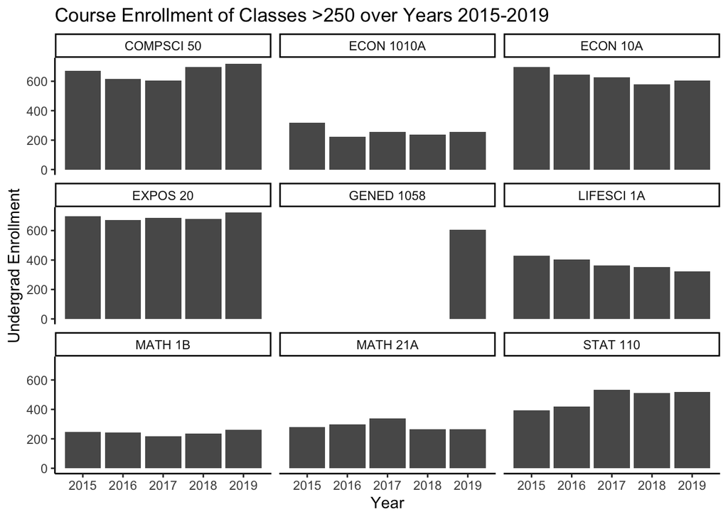